# examples_0416

$$L~=~\frac{2}{9}C$$
$$L~=~\frac{2}{9}d\pi$$
$$L~=~\frac{2}{9}2\pi r$$
$$L~\approx~\frac{2}{9}(25.1327412)$$
$$L~\approx~5.5850536$$

A circle with radius $r=5$ centimeters is cut into 8 congruent sectors. A length of red string is pulled around the circle, and the string is exactly long enough to span the arc of 7 adjacent sectors, as shown in the diagram below.

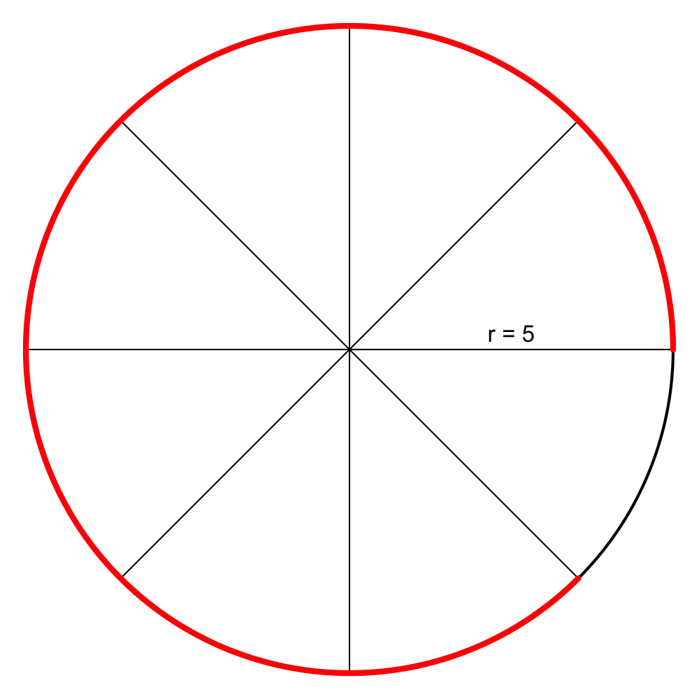

How long, in centimeters, is the red string? Please answer as a decimal approximation accurate within $\pm 0.01$ centimeters.

Find the [diameter](https://en.wikipedia.org/wiki/Diameter).

$$d=2r$$
$$d=2\cdot5$$
$$d=10$$

Find the [circumference](https://en.wikipedia.org/wiki/Circumference).

$$C = \pi d$$
$$C = \pi \cdot 10$$
$$C~\approx~31.4159265$$

The [string's length](https://en.wikipedia.org/wiki/Circular_arc) is $\frac{7}{8}$ of the circumference.

$$L~=~\frac{7}{8}C$$
$$L~=~\frac{7}{8}d\pi$$
$$L~=~\frac{7}{8}2\pi r$$
$$L~\approx~\frac{7}{8}(31.4159265)$$
$$L~\approx~27.4889357$$

A length of red string is pulled around the circle with radius $r=4$. The red string [subtends](https://en.wikipedia.org/wiki/Subtended_angle) a [central angle](https://en.wikipedia.org/wiki/Central_angle) with a degree measure of 307°, as shown in the diagram below.

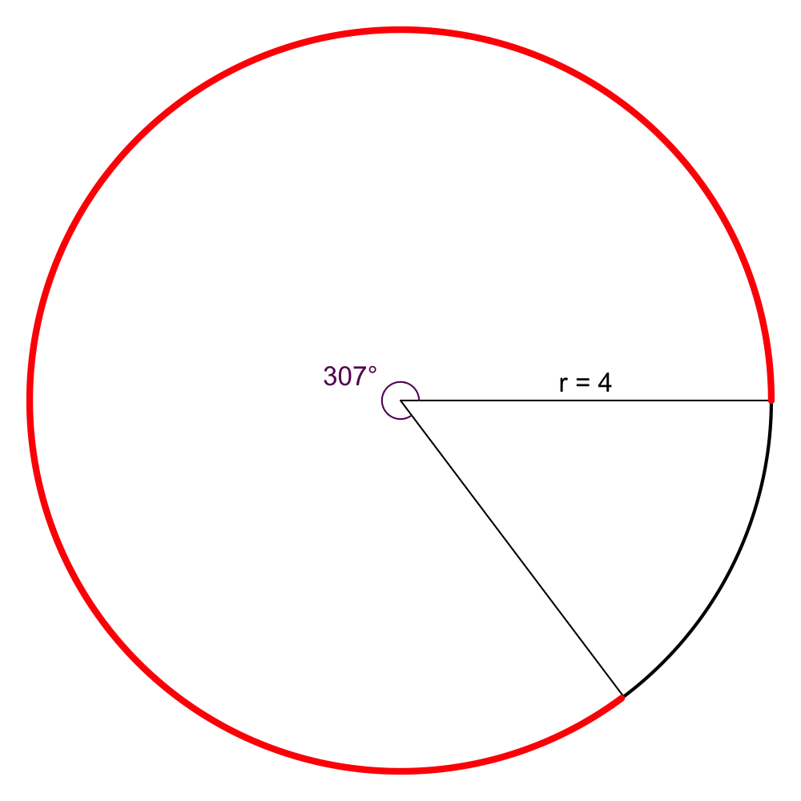

How long, in centimeters, is the red string? Please answer as a decimal approximation accurate within $\pm 0.01$ centimeters.

Find the [diameter](https://en.wikipedia.org/wiki/Diameter).

$$d=2r$$
$$d=2\cdot4$$
$$d=8$$

Find the [circumference](https://en.wikipedia.org/wiki/Circumference).

$$C = \pi d$$
$$C = \pi \cdot 8$$
$$C~\approx~25.1327412$$

Remember, there are $360^{\circ}$ in a full circle. The [string's length](https://en.wikipedia.org/wiki/Circular_arc) is $\frac{307}{360}$ of the circumference.

$$L~=~\frac{307}{360}C$$
$$L~=~\frac{307}{360}d\pi$$
$$L~=~\frac{307}{360}2\pi r$$
$$L~\approx~\frac{307}{360}(25.1327412)$$
$$L~\approx~21.4326432$$

A length of red string is pulled around the circle with radius $r=4$. The red string [subtends](https://en.wikipedia.org/wiki/Subtended_angle) a [central angle](https://en.wikipedia.org/wiki/Central_angle) with a degree measure of 295°, as shown in the diagram below.

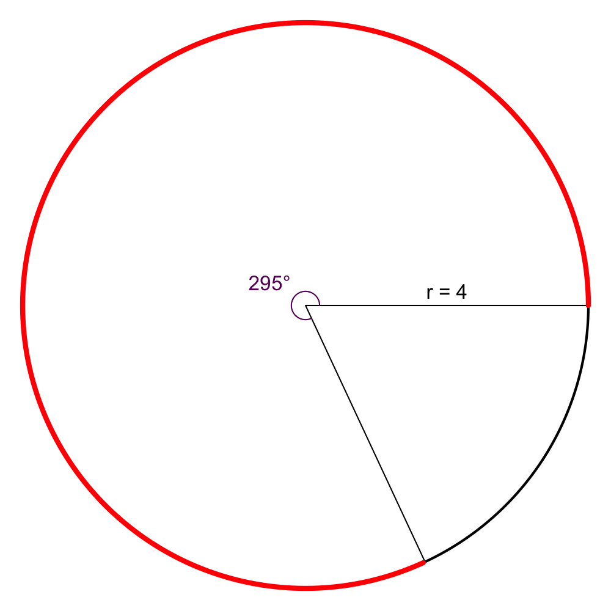

How long, in centimeters, is the red string? Please answer as a decimal approximation accurate within $\pm 0.01$ centimeters.

Find the [diameter](https://en.wikipedia.org/wiki/Diameter).

$$d=2r$$
$$d=2\cdot4$$
$$d=8$$

Find the [circumference](https://en.wikipedia.org/wiki/Circumference).

$$C = \pi d$$
$$C = \pi \cdot 8$$
$$C~\approx~25.1327412$$

Remember, there are $360^{\circ}$ in a full circle. The [string's length](https://en.wikipedia.org/wiki/Circular_arc) is $\frac{295}{360}$ of the circumference.

$$L~=~\frac{295}{360}C$$
$$L~=~\frac{295}{360}d\pi$$
$$L~=~\frac{295}{360}2\pi r$$
$$L~\approx~\frac{295}{360}(25.1327412)$$
$$L~\approx~20.5948852$$

A length of red string is pulled around the circle with radius $r=6$. The red string [subtends](https://en.wikipedia.org/wiki/Subtended_angle) a [central angle](https://en.wikipedia.org/wiki/Central_angle) with a degree measure of 102°, as shown in the diagram below.

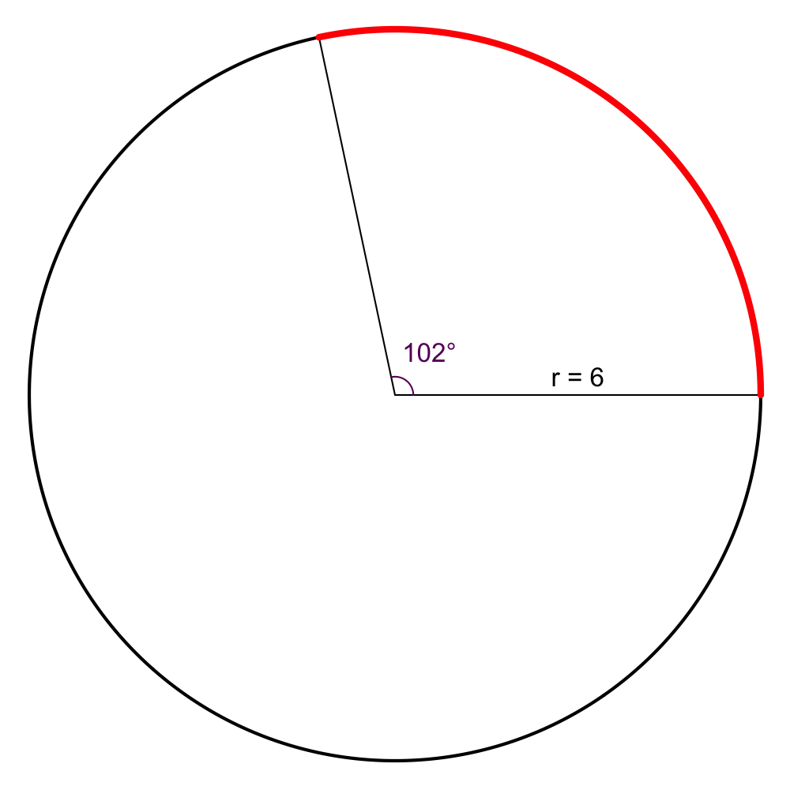

How long, in centimeters, is the red string? Please answer as a decimal approximation accurate within $\pm 0.01$ centimeters.

Find the [diameter](https://en.wikipedia.org/wiki/Diameter).

$$d=2r$$
$$d=2\cdot6$$
$$d=12$$

Find the [circumference](https://en.wikipedia.org/wiki/Circumference).

$$C = \pi d$$
$$C = \pi \cdot 12$$
$$C~\approx~37.6991118$$

Remember, there are $360^{\circ}$ in a full circle. The [string's length](https://en.wikipedia.org/wiki/Circular_arc) is $\frac{102}{360}$ of the circumference.

$$L~=~\frac{102}{360}C$$
$$L~=~\frac{102}{360}d\pi$$
$$L~=~\frac{102}{360}2\pi r$$
$$L~\approx~\frac{102}{360}(37.6991118)$$
$$L~\approx~10.681415$$

A length of red string is pulled around the circle with radius $r=6$. The red string [subtends](https://en.wikipedia.org/wiki/Subtended_angle) a [central angle](https://en.wikipedia.org/wiki/Central_angle) with a degree measure of 325°, as shown in the diagram below.

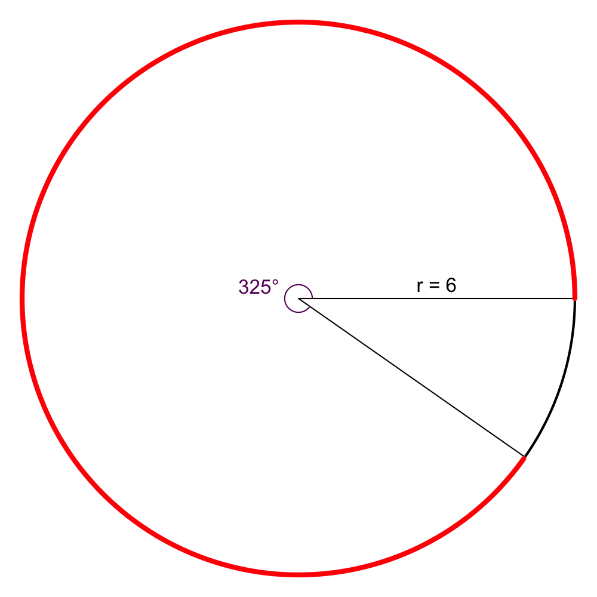

How long, in centimeters, is the red string? Please answer as a decimal approximation accurate within $\pm 0.01$ centimeters.

Find the [diameter](https://en.wikipedia.org/wiki/Diameter).

$$d=2r$$
$$d=2\cdot6$$
$$d=12$$

Find the [circumference](https://en.wikipedia.org/wiki/Circumference).

$$C = \pi d$$
$$C = \pi \cdot 12$$
$$C~\approx~37.6991118$$

Remember, there are $360^{\circ}$ in a full circle. The [string's length](https://en.wikipedia.org/wiki/Circular_arc) is $\frac{325}{360}$ of the circumference.

$$L~=~\frac{325}{360}C$$
$$L~=~\frac{325}{360}d\pi$$
$$L~=~\frac{325}{360}2\pi r$$
$$L~\approx~\frac{325}{360}(37.6991118)$$
$$L~\approx~34.0339204$$

A length of red string is pulled around the circle with radius $r=8$. The red string [subtends](https://en.wikipedia.org/wiki/Subtended_angle) a [central angle](https://en.wikipedia.org/wiki/Central_angle) with a degree measure of $\psi$°, and the red string also subtends an **[inscribed angle](https://en.wikipedia.org/wiki/Inscribed_angle)** with degree measure of 28°.

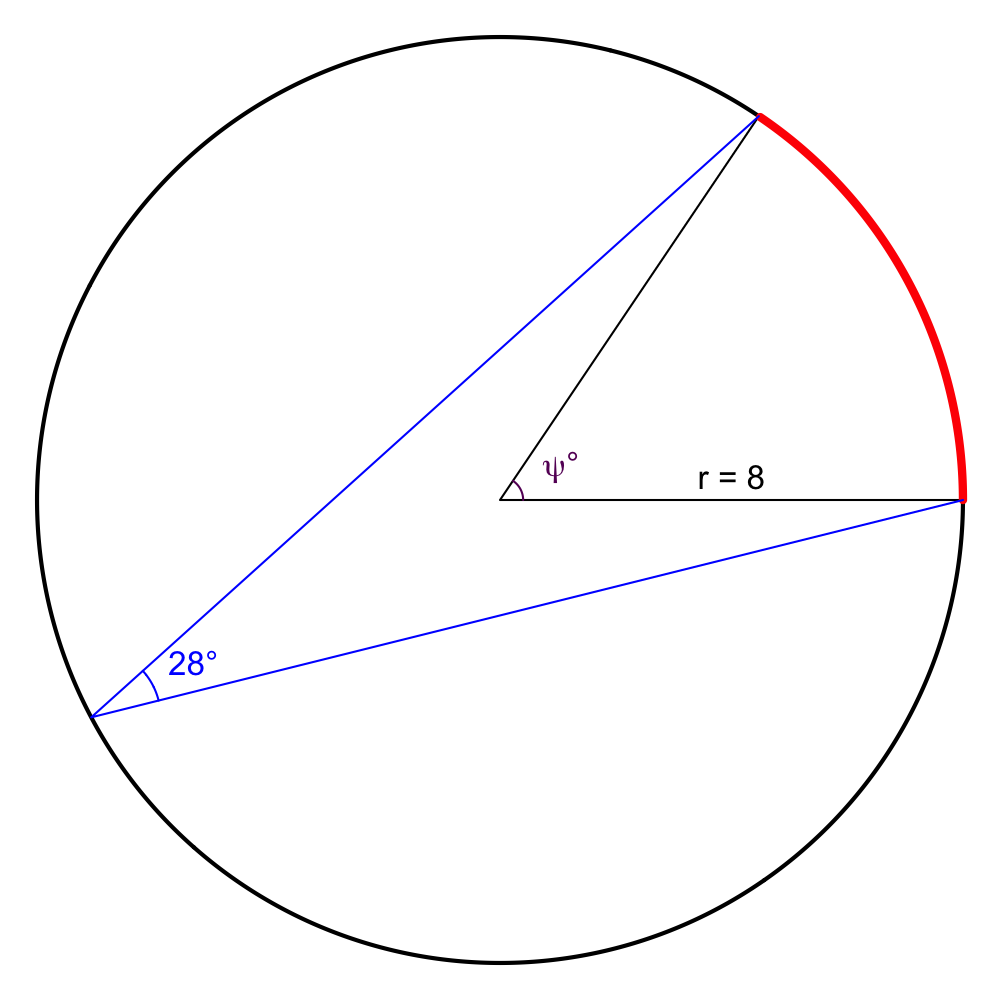

How long, in centimeters, is the red string? Please answer as a decimal approximation accurate within $\pm 0.01$ centimeters.

The **[inscribed angle theorem](https://en.wikipedia.org/wiki/Inscribed_angle#Statement)** states that an angle $\theta$ inscribed in a circle is half of the central angle $2\theta$ that intercepts the same arc on the circle. Surprisingly, this is independent of where the inscribed angle sits on the circle. I find [this animation](https://en.wikipedia.org/wiki/Inscribed_angle#/media/File:ArcCapable.gif) helpful. Please take a moment to internalize this theorem, as it shows up frequently on standardized tests.

Anyway, for this problem, from the inscribed-angle theorem, we know $\psi=2\cdot 28=56$. In other words, our central angle is twice the corresponding inscribed angle.

Find the [diameter](https://en.wikipedia.org/wiki/Diameter).

$$d=2r$$
$$d=2\cdot8$$
$$d=16$$

Find the [circumference](https://en.wikipedia.org/wiki/Circumference).

$$C = \pi d$$
$$C = \pi \cdot 16$$
$$C~\approx~50.2654825$$

Remember, there are $360^{\circ}$ in a full circle. The [string's length](https://en.wikipedia.org/wiki/Circular_arc) is $\frac{56}{360}$ of the circumference.

$$L~=~\frac{56}{360}C$$
$$L~=~\frac{56}{360}d\pi$$
$$L~=~\frac{56}{360}2\pi r$$
$$L~\approx~\frac{56}{360}(50.2654825)$$
$$L~\approx~7.819075$$

A length of red string is pulled around the circle with radius $r=4$. The red string [subtends](https://en.wikipedia.org/wiki/Subtended_angle) a [central angle](https://en.wikipedia.org/wiki/Central_angle) with a degree measure of $\psi$°, and the red string also subtends an **[inscribed angle](https://en.wikipedia.org/wiki/Inscribed_angle)** with degree measure of 84°.

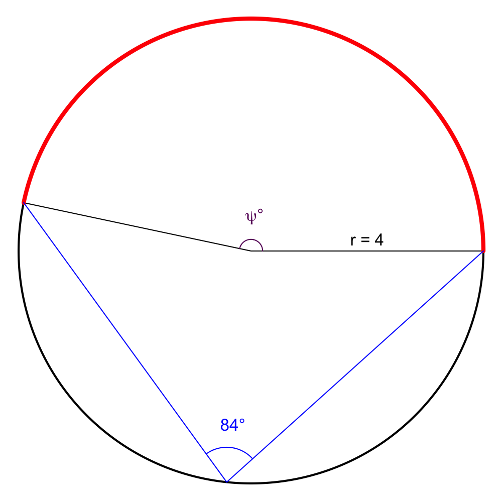

How long, in centimeters, is the red string? Please answer as a decimal approximation accurate within $\pm 0.01$ centimeters.

The **[inscribed angle theorem](https://en.wikipedia.org/wiki/Inscribed_angle#Statement)** states that an angle $\theta$ inscribed in a circle is half of the central angle $2\theta$ that intercepts the same arc on the circle. Surprisingly, this is independent of where the inscribed angle sits on the circle. I find [this animation](https://en.wikipedia.org/wiki/Inscribed_angle#/media/File:ArcCapable.gif) helpful. Please take a moment to internalize this theorem, as it shows up frequently on standardized tests.

Anyway, for this problem, from the inscribed-angle theorem, we know $\psi=2\cdot 84=168$. In other words, our central angle is twice the corresponding inscribed angle.

Find the [diameter](https://en.wikipedia.org/wiki/Diameter).

$$d=2r$$
$$d=2\cdot4$$
$$d=8$$

Find the [circumference](https://en.wikipedia.org/wiki/Circumference).

$$C = \pi d$$
$$C = \pi \cdot 8$$
$$C~\approx~25.1327412$$

Remember, there are $360^{\circ}$ in a full circle. The [string's length](https://en.wikipedia.org/wiki/Circular_arc) is $\frac{168}{360}$ of the circumference.

$$L~=~\frac{168}{360}C$$
$$L~=~\frac{168}{360}d\pi$$
$$L~=~\frac{168}{360}2\pi r$$
$$L~\approx~\frac{168}{360}(25.1327412)$$
$$L~\approx~11.7286126$$

A length of red string is pulled around the circle with radius $r=7$. The red string [subtends](https://en.wikipedia.org/wiki/Subtended_angle) a [central angle](https://en.wikipedia.org/wiki/Central_angle) with a degree measure of $\psi$°, and the red string also subtends an **[inscribed angle](https://en.wikipedia.org/wiki/Inscribed_angle)** with degree measure of 93°.

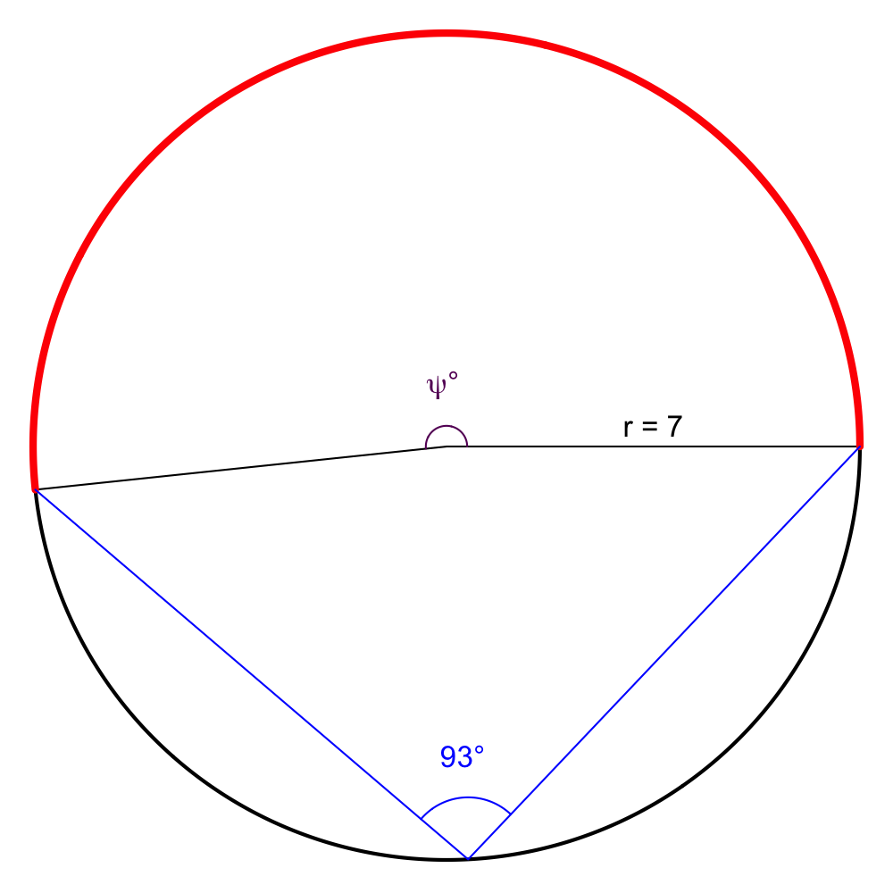

How long, in centimeters, is the red string? Please answer as a decimal approximation accurate within $\pm 0.01$ centimeters.

The **[inscribed angle theorem](https://en.wikipedia.org/wiki/Inscribed_angle#Statement)** states that an angle $\theta$ inscribed in a circle is half of the central angle $2\theta$ that intercepts the same arc on the circle. Surprisingly, this is independent of where the inscribed angle sits on the circle. I find [this animation](https://en.wikipedia.org/wiki/Inscribed_angle#/media/File:ArcCapable.gif) helpful. Please take a moment to internalize this theorem, as it shows up frequently on standardized tests.

Anyway, for this problem, from the inscribed-angle theorem, we know $\psi=2\cdot 93=186$. In other words, our central angle is twice the corresponding inscribed angle.

Find the [diameter](https://en.wikipedia.org/wiki/Diameter).

$$d=2r$$
$$d=2\cdot7$$
$$d=14$$

Find the [circumference](https://en.wikipedia.org/wiki/Circumference).

$$C = \pi d$$
$$C = \pi \cdot 14$$
$$C~\approx~43.9822972$$

Remember, there are $360^{\circ}$ in a full circle. The [string's length](https://en.wikipedia.org/wiki/Circular_arc) is $\frac{186}{360}$ of the circumference.

$$L~=~\frac{186}{360}C$$
$$L~=~\frac{186}{360}d\pi$$
$$L~=~\frac{186}{360}2\pi r$$
$$L~\approx~\frac{186}{360}(43.9822972)$$
$$L~\approx~22.7241869$$

A length of red string is pulled around the circle with radius $r=8$. The red string [subtends](https://en.wikipedia.org/wiki/Subtended_angle) a [central angle](https://en.wikipedia.org/wiki/Central_angle) with a degree measure of $\psi$°, and the red string also subtends an **[inscribed angle](https://en.wikipedia.org/wiki/Inscribed_angle)** with degree measure of 66°.

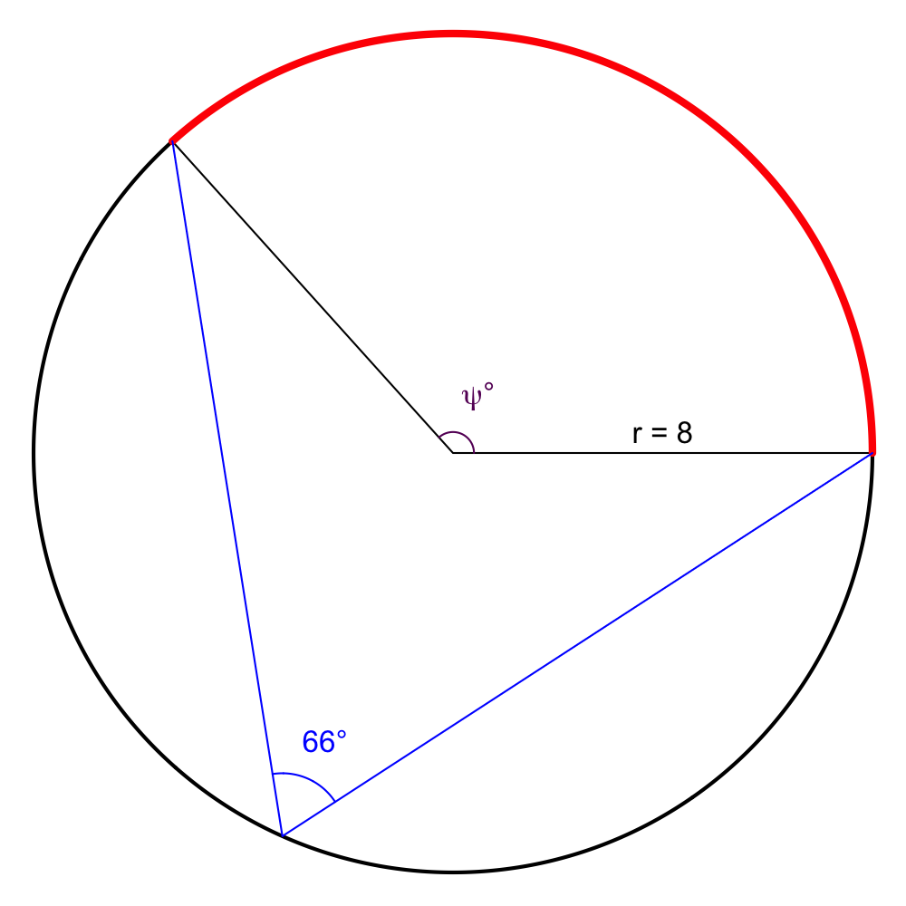

How long, in centimeters, is the red string? Please answer as a decimal approximation accurate within $\pm 0.01$ centimeters.

The **[inscribed angle theorem](https://en.wikipedia.org/wiki/Inscribed_angle#Statement)** states that an angle $\theta$ inscribed in a circle is half of the central angle $2\theta$ that intercepts the same arc on the circle. Surprisingly, this is independent of where the inscribed angle sits on the circle. I find [this animation](https://en.wikipedia.org/wiki/Inscribed_angle#/media/File:ArcCapable.gif) helpful. Please take a moment to internalize this theorem, as it shows up frequently on standardized tests.

Anyway, for this problem, from the inscribed-angle theorem, we know $\psi=2\cdot 66=132$. In other words, our central angle is twice the corresponding inscribed angle.

Find the [diameter](https://en.wikipedia.org/wiki/Diameter).

$$d=2r$$
$$d=2\cdot8$$
$$d=16$$

Find the [circumference](https://en.wikipedia.org/wiki/Circumference).

$$C = \pi d$$
$$C = \pi \cdot 16$$
$$C~\approx~50.2654825$$

Remember, there are $360^{\circ}$ in a full circle. The [string's length](https://en.wikipedia.org/wiki/Circular_arc) is $\frac{132}{360}$ of the circumference.

$$L~=~\frac{132}{360}C$$
$$L~=~\frac{132}{360}d\pi$$
$$L~=~\frac{132}{360}2\pi r$$
$$L~\approx~\frac{132}{360}(50.2654825)$$
$$L~\approx~18.4306769$$

Two concentric circles have radii $r_1=1$ meters and $r_2=4.04$ meters. A central angle subtends similar arcs on both circles: a blue arc on the smaller circle and a red arc on the larger circle. The blue arc length is 1.2 meters, as shown in the diagram below.

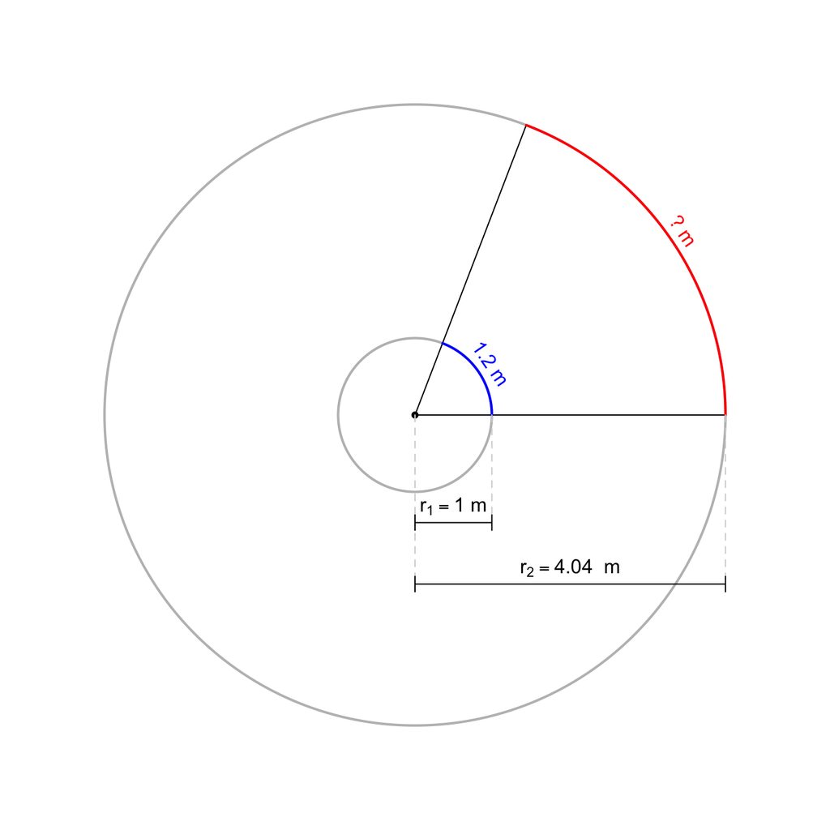

What is the length, in meters, of the red arc? *The tolerance is set to $\pm0.01$ meters.*

Okay, this might seem absurdly easy if you are comfortable with similarity.

$$\frac{1}{1.2} ~=~
\frac{4.04}{?}$$

$$?~=~ 1.2\cdot 4.04 ~=~
4.848$$

I am trying to introduce the **[radian](https://en.wikipedia.org/wiki/Radian)**, which is the arc length of a unit circle.

- Massachusetts learning objective F-TF.A.1:
  - Understand radian measure of an angle as the length of the arc on the unit circle subtended by the angle.

In this case, the central angle is 69°, which is approximately equivalent to 1.2 radians. To convert between degrees and radians, we can multiply by $\frac{\pi}{180^{\circ}}$ to go from degrees to radians or multiply by $\frac{180^{\circ}}{\pi}$ to convert from radians to degrees.

As you progress in math, you'll use **radians** by default, not degrees. One of the best reasons for this depends on concepts learned in calculus... but in short... if we use radians, then the [derivative](https://en.wikipedia.org/wiki/Derivative) of $\sin(x)$ is simply $\cos(x)$. If we used degrees, then calculus with trigonometric functions would be more annoying.

If you look up [circular arc](https://en.wikipedia.org/wiki/Circular_arc#Length) on wikipedia, you'll see a formula relating the arc length ($L$) to radius ($r$) and the central angle **measured in radians** ($\theta$).
$$L~=~r\theta$$

So, in our case:

$$L~=~(4.04)(1.2)$$

$$L~=~4.848~\text{m}$$

Two concentric circles have radii $r_1=1$ meters and $r_2=3.36$ meters. A central angle subtends similar arcs on both circles: a blue arc on the smaller circle and a red arc on the larger circle. The blue arc length is 3.35 meters, as shown in the diagram below.

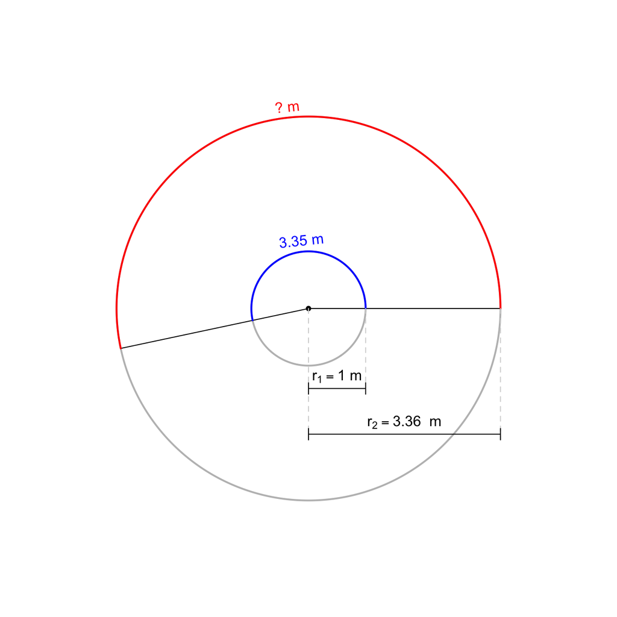

What is the length, in meters, of the red arc? *The tolerance is set to $\pm0.01$ meters.*

Okay, this might seem absurdly easy if you are comfortable with similarity.

$$\frac{1}{3.35} ~=~
\frac{3.36}{?}$$

$$?~=~ 3.35\cdot 3.36 ~=~
11.256$$

I am trying to introduce the **[radian](https://en.wikipedia.org/wiki/Radian)**, which is the arc length of a unit circle.

- Massachusetts learning objective F-TF.A.1:
  - Understand radian measure of an angle as the length of the arc on the unit circle subtended by the angle.

In this case, the central angle is 192°, which is approximately equivalent to 3.35 radians. To convert between degrees and radians, we can multiply by $\frac{\pi}{180^{\circ}}$ to go from degrees to radians or multiply by $\frac{180^{\circ}}{\pi}$ to convert from radians to degrees.

As you progress in math, you'll use **radians** by default, not degrees. One of the best reasons for this depends on concepts learned in calculus... but in short... if we use radians, then the [derivative](https://en.wikipedia.org/wiki/Derivative) of $\sin(x)$ is simply $\cos(x)$. If we used degrees, then calculus with trigonometric functions would be more annoying.

If you look up [circular arc](https://en.wikipedia.org/wiki/Circular_arc#Length) on wikipedia, you'll see a formula relating the arc length ($L$) to radius ($r$) and the central angle **measured in radians** ($\theta$).
$$L~=~r\theta$$

So, in our case:

$$L~=~(3.36)(3.35)$$

$$L~=~11.256~\text{m}$$

Two concentric circles have radii $r_1=1$ meters and $r_2=3.79$ meters. A central angle subtends similar arcs on both circles: a blue arc on the smaller circle and a red arc on the larger circle. The blue arc length is 1.19 meters, as shown in the diagram below.

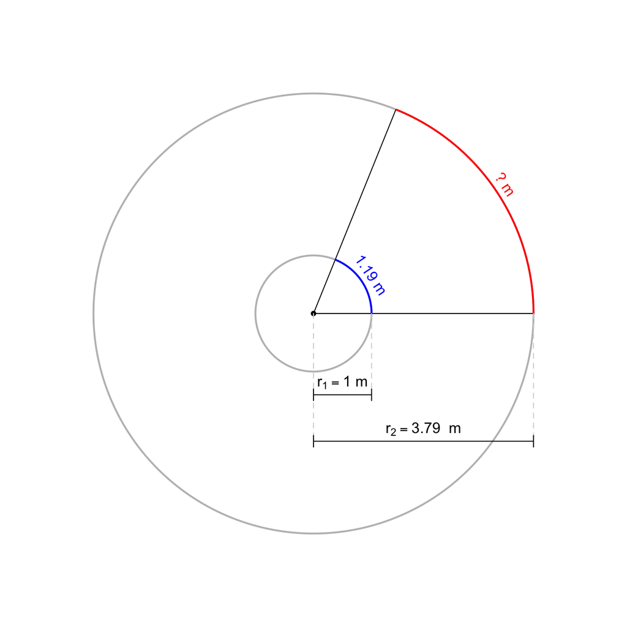

What is the length, in meters, of the red arc? *The tolerance is set to $\pm0.01$ meters.*

Okay, this might seem absurdly easy if you are comfortable with similarity.

$$\frac{1}{1.19} ~=~
\frac{3.79}{?}$$

$$?~=~ 1.19\cdot 3.79 ~=~
4.5101$$

I am trying to introduce the **[radian](https://en.wikipedia.org/wiki/Radian)**, which is the arc length of a unit circle.

- Massachusetts learning objective F-TF.A.1:
  - Understand radian measure of an angle as the length of the arc on the unit circle subtended by the angle.

In this case, the central angle is 68°, which is approximately equivalent to 1.19 radians. To convert between degrees and radians, we can multiply by $\frac{\pi}{180^{\circ}}$ to go from degrees to radians or multiply by $\frac{180^{\circ}}{\pi}$ to convert from radians to degrees.

As you progress in math, you'll use **radians** by default, not degrees. One of the best reasons for this depends on concepts learned in calculus... but in short... if we use radians, then the [derivative](https://en.wikipedia.org/wiki/Derivative) of $\sin(x)$ is simply $\cos(x)$. If we used degrees, then calculus with trigonometric functions would be more annoying.

If you look up [circular arc](https://en.wikipedia.org/wiki/Circular_arc#Length) on wikipedia, you'll see a formula relating the arc length ($L$) to radius ($r$) and the central angle **measured in radians** ($\theta$).
$$L~=~r\theta$$

So, in our case:

$$L~=~(3.79)(1.19)$$

$$L~=~4.5101~\text{m}$$

Two concentric circles have radii $r_1=1$ meters and $r_2=3.46$ meters. A central angle subtends similar arcs on both circles: a blue arc on the smaller circle and a red arc on the larger circle. The blue arc length is 4.4 meters, as shown in the diagram below.

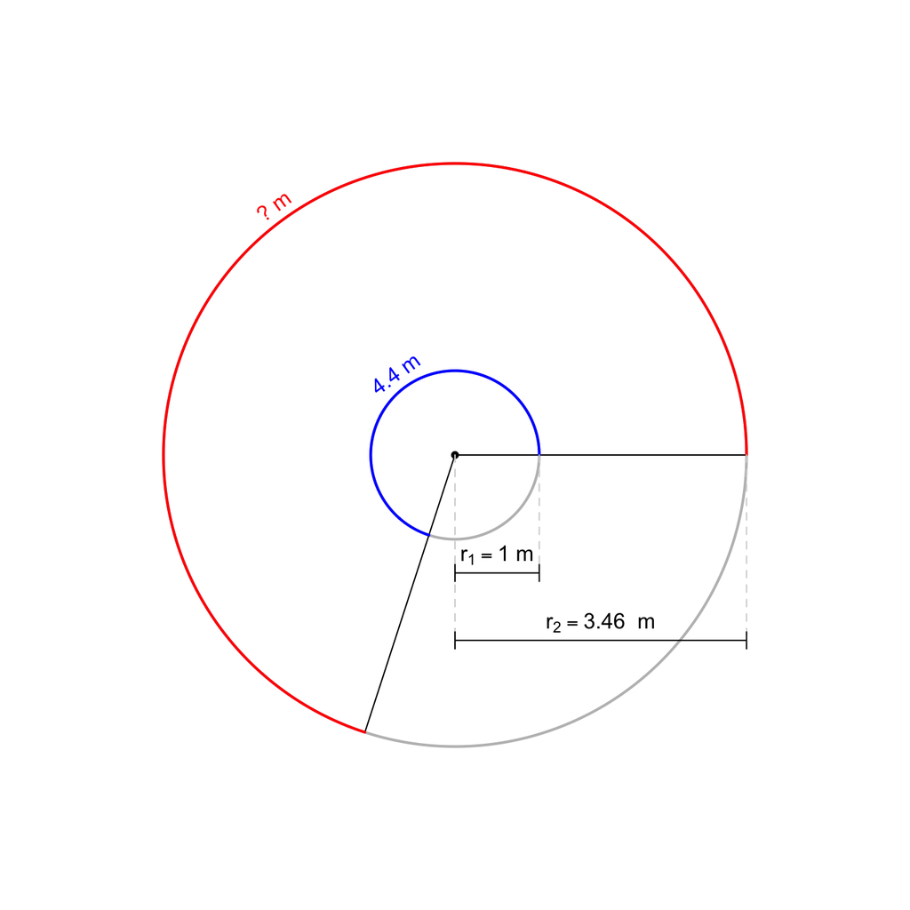

What is the length, in meters, of the red arc? *The tolerance is set to $\pm0.01$ meters.*

Okay, this might seem absurdly easy if you are comfortable with similarity.

$$\frac{1}{4.4} ~=~
\frac{3.46}{?}$$

$$?~=~ 4.4\cdot 3.46 ~=~
15.224$$

I am trying to introduce the **[radian](https://en.wikipedia.org/wiki/Radian)**, which is the arc length of a unit circle.

- Massachusetts learning objective F-TF.A.1:
  - Understand radian measure of an angle as the length of the arc on the unit circle subtended by the angle.

In this case, the central angle is 252°, which is approximately equivalent to 4.4 radians. To convert between degrees and radians, we can multiply by $\frac{\pi}{180^{\circ}}$ to go from degrees to radians or multiply by $\frac{180^{\circ}}{\pi}$ to convert from radians to degrees.

As you progress in math, you'll use **radians** by default, not degrees. One of the best reasons for this depends on concepts learned in calculus... but in short... if we use radians, then the [derivative](https://en.wikipedia.org/wiki/Derivative) of $\sin(x)$ is simply $\cos(x)$. If we used degrees, then calculus with trigonometric functions would be more annoying.

If you look up [circular arc](https://en.wikipedia.org/wiki/Circular_arc#Length) on wikipedia, you'll see a formula relating the arc length ($L$) to radius ($r$) and the central angle **measured in radians** ($\theta$).
$$L~=~r\theta$$

So, in our case:

$$L~=~(3.46)(4.4)$$

$$L~=~15.224~\text{m}$$

Two concentric circles have radii $r_1=1$ meters and $r_2=3.12$ meters. A central angle subtends similar arcs on both circles: a blue arc on the smaller circle and a red arc on the larger circle. The red arc length is 4.31 meters, as shown in the diagram below.

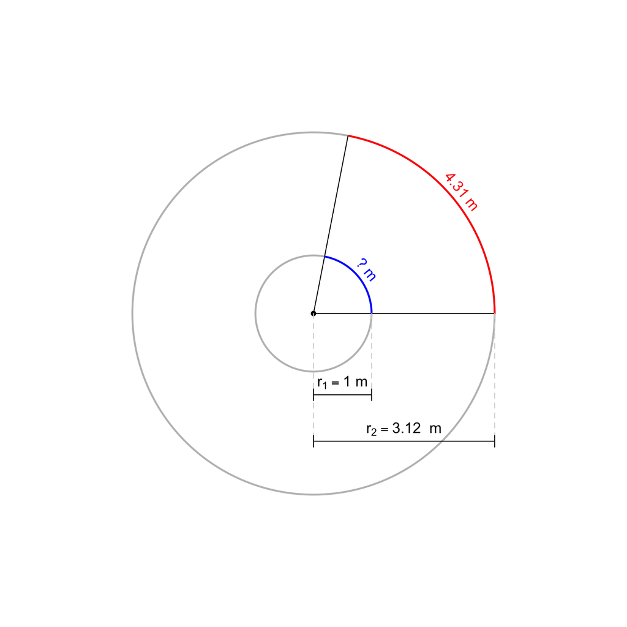

What is the length, in meters, of the blue arc? *The tolerance is set to $\pm0.01$ meters.*

Okay, this might seem absurdly easy if you are comfortable with similarity.

$$\frac{1}{?} ~=~
\frac{3.12}{4.31}$$

$$?~=~ \frac{4.31}{3.12} ~=~
1.3814103$$

I am trying to introduce the **[radian](https://en.wikipedia.org/wiki/Radian)**, which is the arc length of a unit circle.

- Massachusetts learning objective F-TF.A.1:
  - Understand radian measure of an angle as the length of the arc on the unit circle subtended by the angle.

If you look up [circular arc](https://en.wikipedia.org/wiki/Circular_arc#Length) on wikipedia, you'll see a formula relating the arc length ($L$) to radius ($r$) and the central angle **measured in radians** ($\theta$).
$$L~=~r\theta$$

So, in our case:

$$4.31~=~(3.12)(\theta)$$

$$\theta~=~\frac{4.31}{3.12}~=~
1.3814103$$

Two concentric circles have radii $r_1=1$ meters and $r_2=4.33$ meters. A central angle subtends similar arcs on both circles: a blue arc on the smaller circle and a red arc on the larger circle. The red arc length is 6.67 meters, as shown in the diagram below.

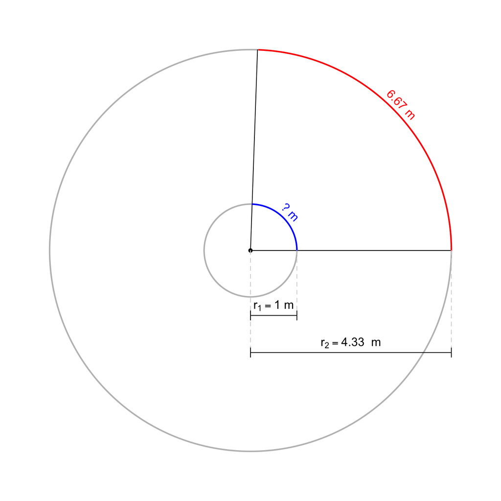

What is the length, in meters, of the blue arc? *The tolerance is set to $\pm0.01$ meters.*

Okay, this might seem absurdly easy if you are comfortable with similarity.

$$\frac{1}{?} ~=~
\frac{4.33}{6.67}$$

$$?~=~ \frac{6.67}{4.33} ~=~
1.5404157$$

I am trying to introduce the **[radian](https://en.wikipedia.org/wiki/Radian)**, which is the arc length of a unit circle.

- Massachusetts learning objective F-TF.A.1:
  - Understand radian measure of an angle as the length of the arc on the unit circle subtended by the angle.

If you look up [circular arc](https://en.wikipedia.org/wiki/Circular_arc#Length) on wikipedia, you'll see a formula relating the arc length ($L$) to radius ($r$) and the central angle **measured in radians** ($\theta$).
$$L~=~r\theta$$

So, in our case:

$$6.67~=~(4.33)(\theta)$$

$$\theta~=~\frac{6.67}{4.33}~=~
1.5404157$$

Two concentric circles have radii $r_1=1$ meters and $r_2=4.17$ meters. A central angle subtends similar arcs on both circles: a blue arc on the smaller circle and a red arc on the larger circle. The red arc length is 9.59 meters, as shown in the diagram below.

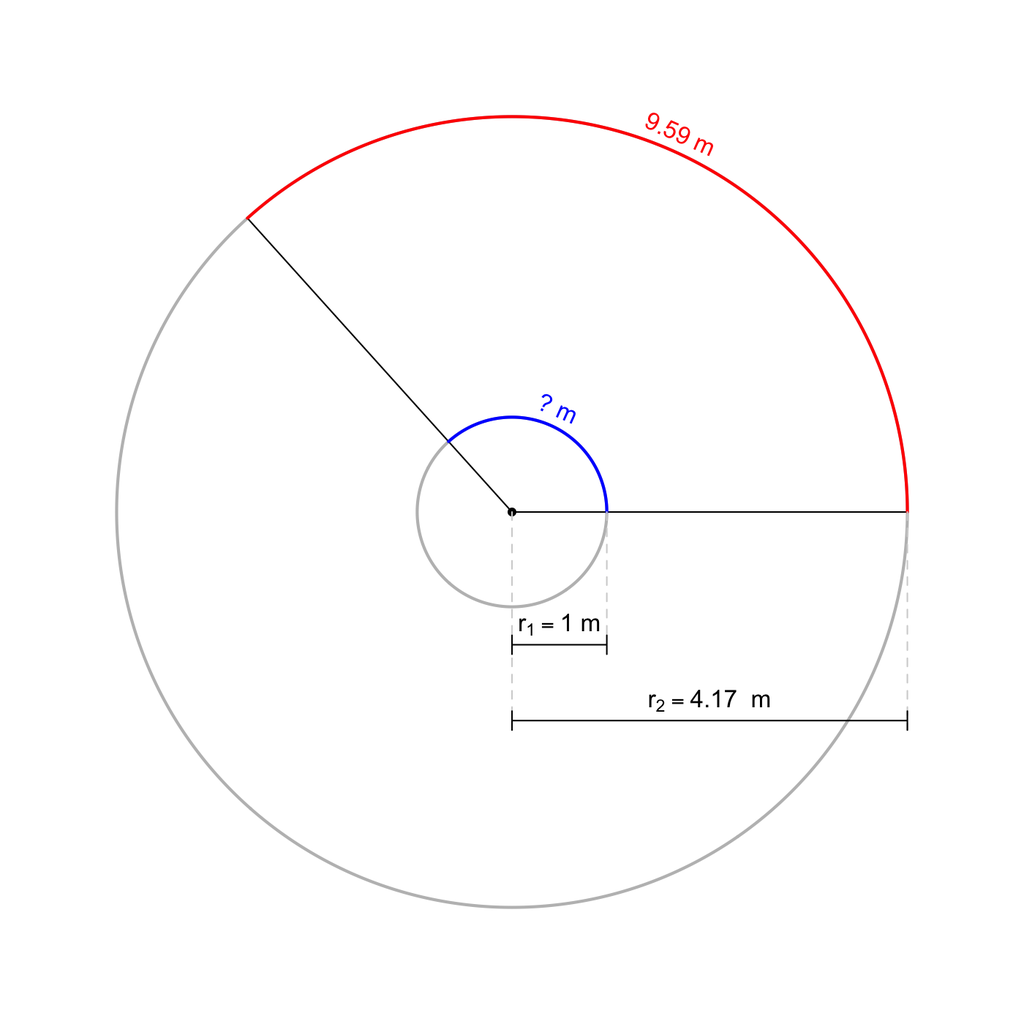

What is the length, in meters, of the blue arc? *The tolerance is set to $\pm0.01$ meters.*

Okay, this might seem absurdly easy if you are comfortable with similarity.

$$\frac{1}{?} ~=~
\frac{4.17}{9.59}$$

$$?~=~ \frac{9.59}{4.17} ~=~
2.2997602$$

I am trying to introduce the **[radian](https://en.wikipedia.org/wiki/Radian)**, which is the arc length of a unit circle.

- Massachusetts learning objective F-TF.A.1:
  - Understand radian measure of an angle as the length of the arc on the unit circle subtended by the angle.

If you look up [circular arc](https://en.wikipedia.org/wiki/Circular_arc#Length) on wikipedia, you'll see a formula relating the arc length ($L$) to radius ($r$) and the central angle **measured in radians** ($\theta$).
$$L~=~r\theta$$

So, in our case:

$$9.59~=~(4.17)(\theta)$$

$$\theta~=~\frac{9.59}{4.17}~=~
2.2997602$$

Two concentric circles have radii $r_1=1$ meters and $r_2=3.35$ meters. A central angle subtends similar arcs on both circles: a blue arc on the smaller circle and a red arc on the larger circle. The red arc length is 5.56 meters, as shown in the diagram below.

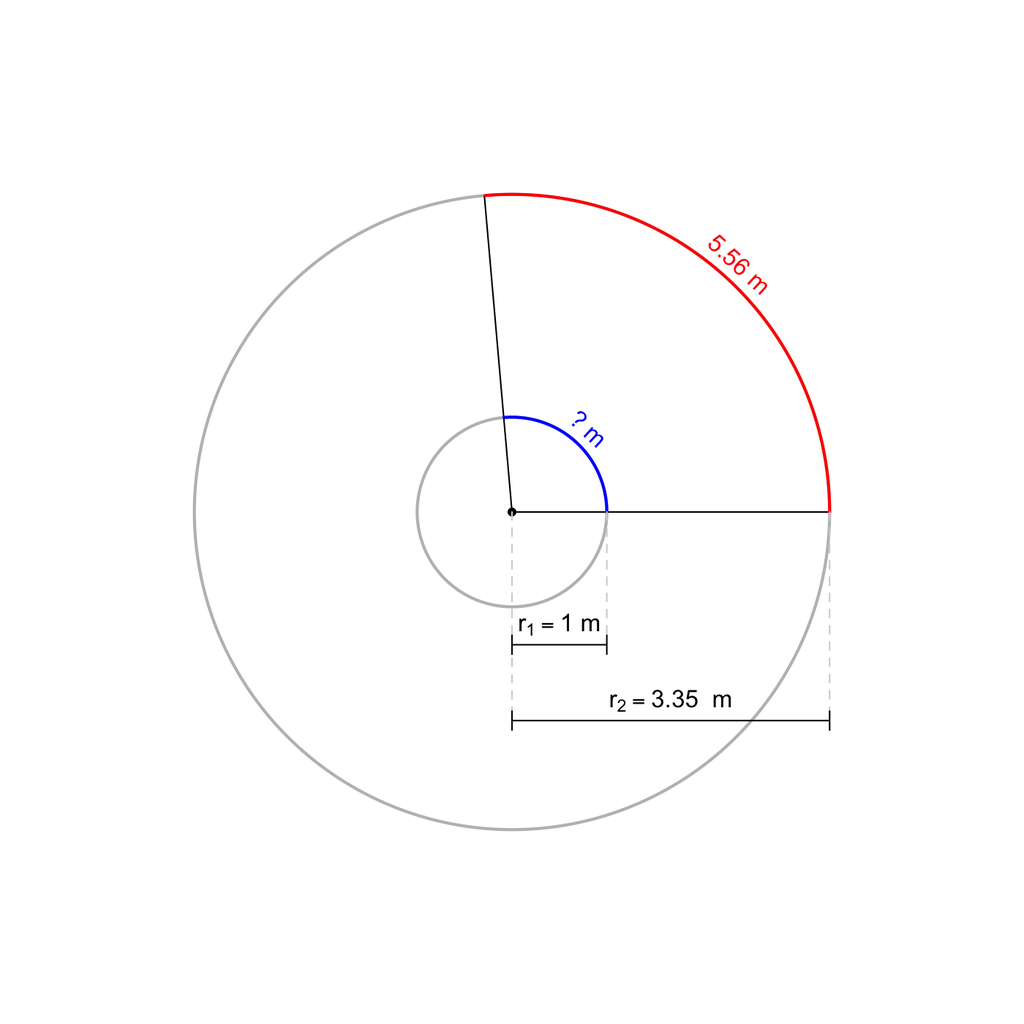

What is the length, in meters, of the blue arc? *The tolerance is set to $\pm0.01$ meters.*

Okay, this might seem absurdly easy if you are comfortable with similarity.

$$\frac{1}{?} ~=~
\frac{3.35}{5.56}$$

$$?~=~ \frac{5.56}{3.35} ~=~
1.6597015$$

I am trying to introduce the **[radian](https://en.wikipedia.org/wiki/Radian)**, which is the arc length of a unit circle.

- Massachusetts learning objective F-TF.A.1:
  - Understand radian measure of an angle as the length of the arc on the unit circle subtended by the angle.

If you look up [circular arc](https://en.wikipedia.org/wiki/Circular_arc#Length) on wikipedia, you'll see a formula relating the arc length ($L$) to radius ($r$) and the central angle **measured in radians** ($\theta$).
$$L~=~r\theta$$

So, in our case:

$$5.56~=~(3.35)(\theta)$$

$$\theta~=~\frac{5.56}{3.35}~=~
1.6597015$$

The radian measure of an angle is the length of the arc on the [unit circle](https://en.wikipedia.org/wiki/Unit_circle) subtended by the angle. In mathematics, radians are the default way to measure an angle.

Consider a circle with a radius of length $r=1$ meter. A [central angle](https://en.wikipedia.org/wiki/Central_angle), in [standard position](https://libraryguides.centennialcollege.ca/c.php?g=716824&p=5112868), subtends an arc of length $3.56$ meters.

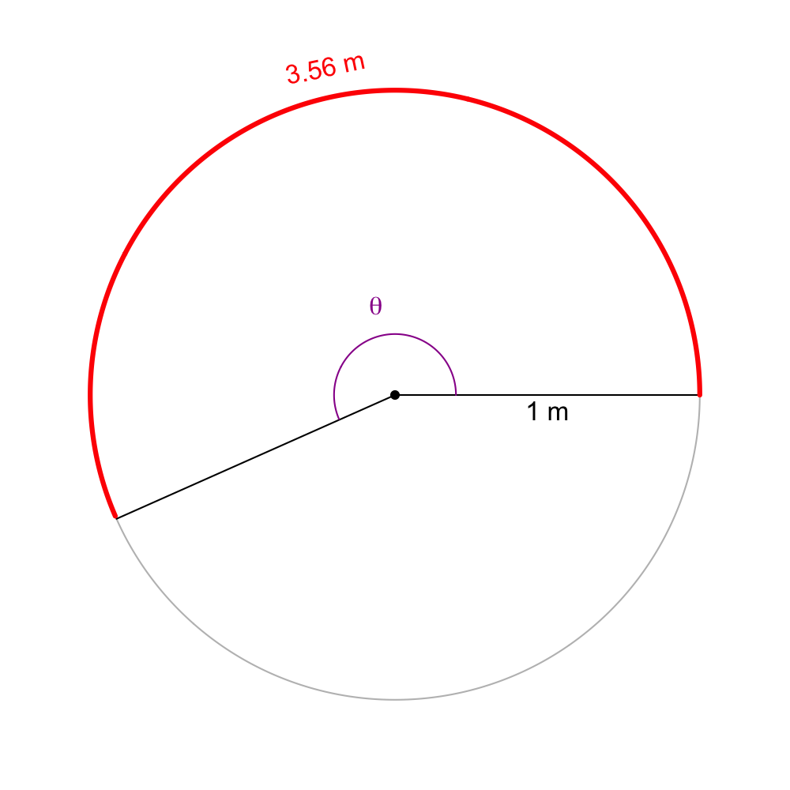

The central angle, measured in degrees, is approximately equal to 204°. However, from the radius and the arc length, you should be able to calculate the angle in radians exactly.

**Find $\theta$ in radians**.

**The radian measure of an angle is the length of the arc on the unit circle subtended by the angle.**

$$\theta=3.56$$

The radian measure of an angle is the length of the arc on the [unit circle](https://en.wikipedia.org/wiki/Unit_circle) subtended by the angle. In mathematics, radians are the default way to measure an angle.

Consider a circle with a radius of length $r=1$ meter. A [central angle](https://en.wikipedia.org/wiki/Central_angle), in [standard position](https://libraryguides.centennialcollege.ca/c.php?g=716824&p=5112868), subtends an arc of length $3.62$ meters.

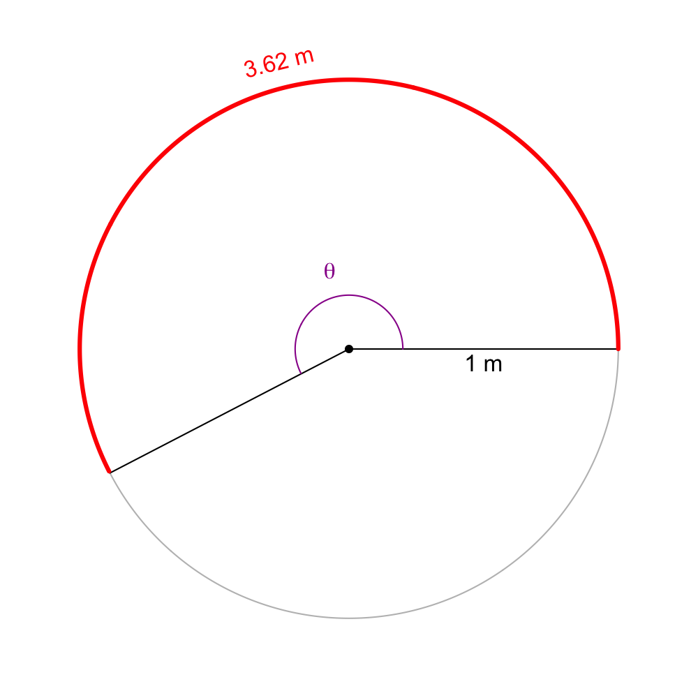

The central angle, measured in degrees, is approximately equal to 207°. However, from the radius and the arc length, you should be able to calculate the angle in radians exactly.

**Find $\theta$ in radians**.

**The radian measure of an angle is the length of the arc on the unit circle subtended by the angle.**

$$\theta=3.62$$

The radian measure of an angle is the length of the arc on the [unit circle](https://en.wikipedia.org/wiki/Unit_circle) subtended by the angle. In mathematics, radians are the default way to measure an angle.

Consider a circle with a radius of length $r=1$ meter. A [central angle](https://en.wikipedia.org/wiki/Central_angle), in [standard position](https://libraryguides.centennialcollege.ca/c.php?g=716824&p=5112868), subtends an arc of length $3.16$ meters.

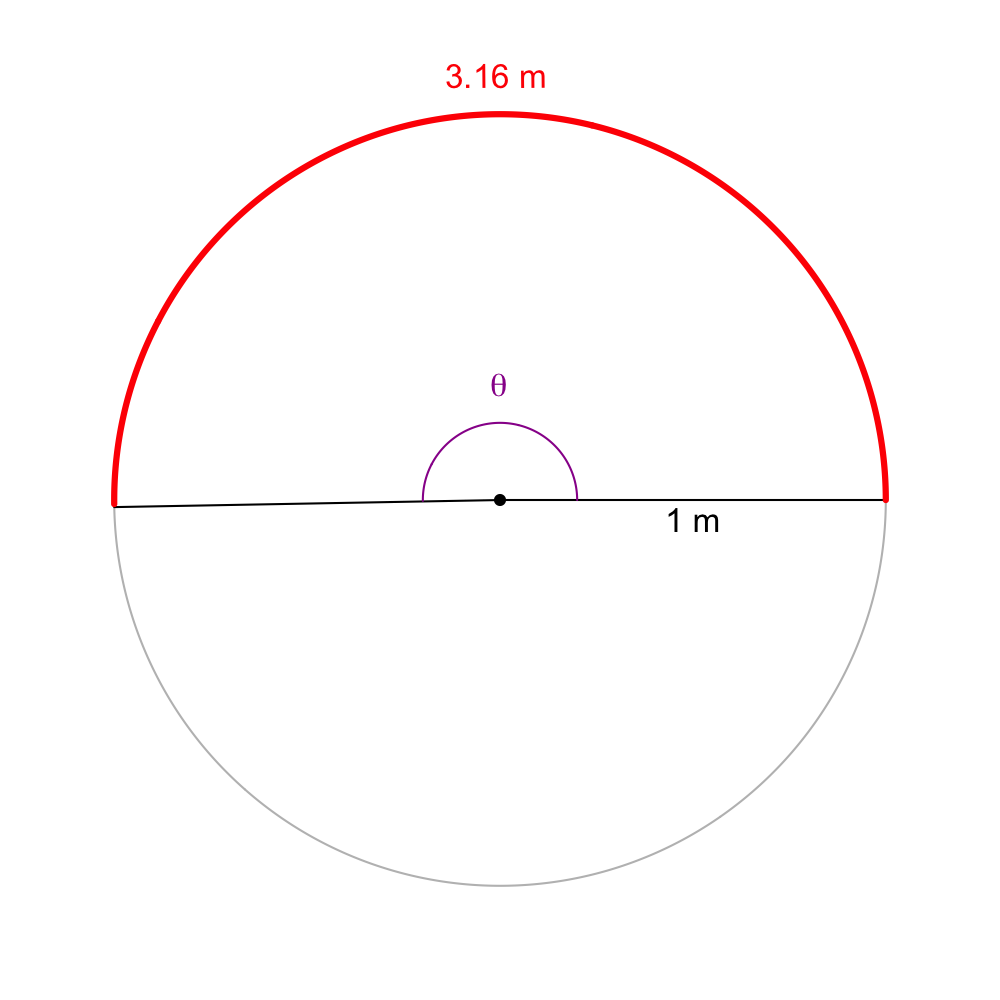

The central angle, measured in degrees, is approximately equal to 181°. However, from the radius and the arc length, you should be able to calculate the angle in radians exactly.

**Find $\theta$ in radians**.

**The radian measure of an angle is the length of the arc on the unit circle subtended by the angle.**

$$\theta=3.16$$

The radian measure of an angle is the length of the arc on the [unit circle](https://en.wikipedia.org/wiki/Unit_circle) subtended by the angle. In mathematics, radians are the default way to measure an angle.

Consider a circle with a radius of length $r=1$ meter. A [central angle](https://en.wikipedia.org/wiki/Central_angle), in [standard position](https://libraryguides.centennialcollege.ca/c.php?g=716824&p=5112868), subtends an arc of length $2.82$ meters.

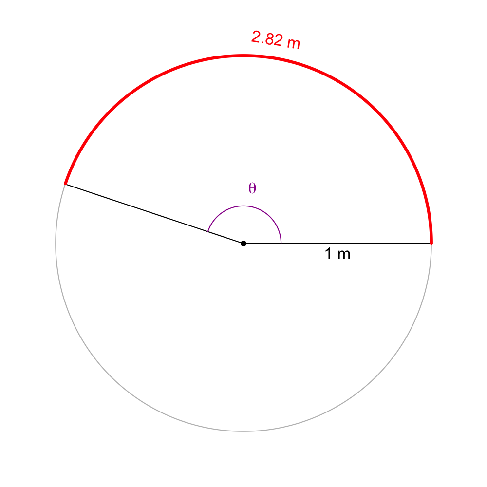

The central angle, measured in degrees, is approximately equal to 162°. However, from the radius and the arc length, you should be able to calculate the angle in radians exactly.

**Find $\theta$ in radians**.

**The radian measure of an angle is the length of the arc on the unit circle subtended by the angle.**

$$\theta=2.82$$

Consider a circle with a radius of length $r=2$ meters. A [central angle](https://en.wikipedia.org/wiki/Central_angle), in [standard position](https://libraryguides.centennialcollege.ca/c.php?g=716824&p=5112868), subtends an arc of length $6$ meters.

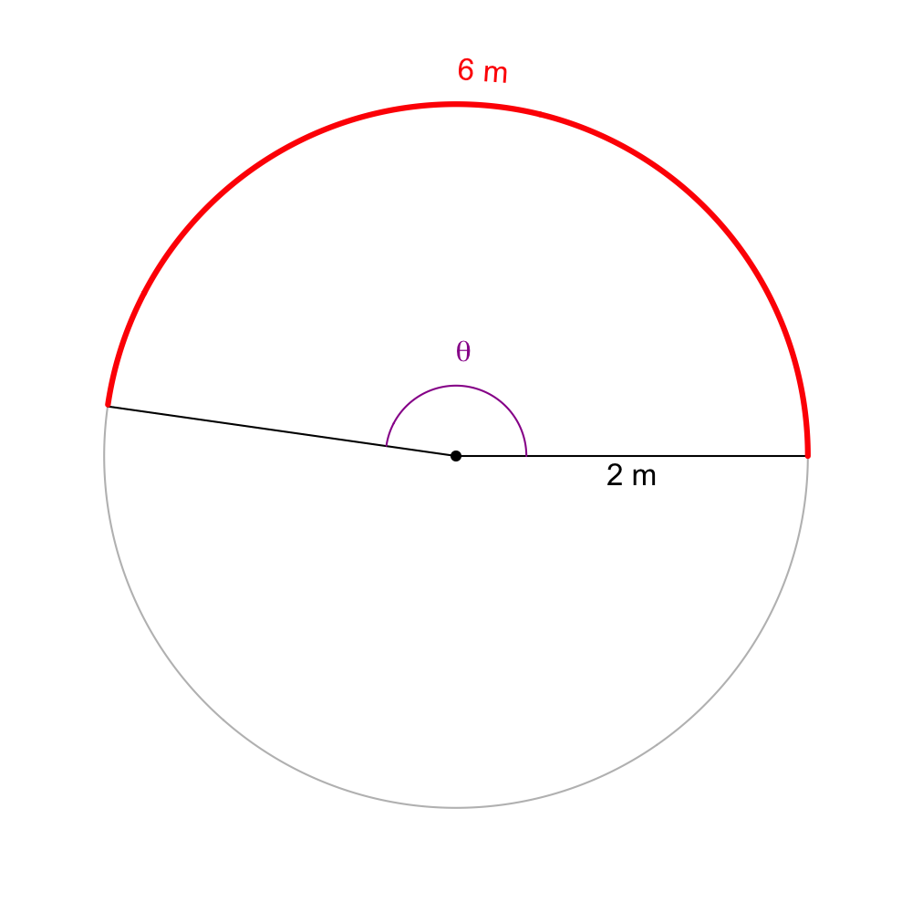

**Find $\theta$ in radians**.

Remember, the radian measure of an angle is the length of the arc on the **[unit circle](https://en.wikipedia.org/wiki/Unit_circle)** subtended by the angle. The circle shown is not a unit circle (its radius is 2), but we can add a unit circle into the drawing.

(Not drawn to scale.)

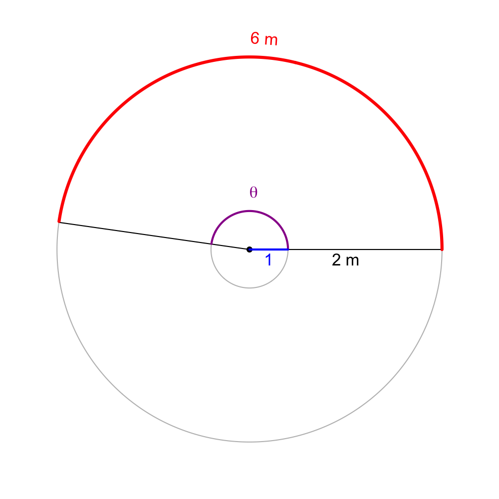

$$\frac{\theta}{6}~=~\frac{1}{2}$$

$$\theta~=~\frac{6}{2}~=~3$$

If you refer to the [wikipedia article on circular arcs](https://en.wikipedia.org/wiki/Circular_arc), you'll see a formula:
$$L=\theta r$$
where $L$ is an arc length on a circle of radius $r$ and with central angle $\theta$ (pronounced "theta"). In our case, we were given $L=6$ and $r=2$, so we can rearrange the formula, solving for $\theta$.

$$\theta = \frac{L}{r} =
\frac{6}{2}$$

Consider a circle with a radius of length $r=5$ meters. A [central angle](https://en.wikipedia.org/wiki/Central_angle), in [standard position](https://libraryguides.centennialcollege.ca/c.php?g=716824&p=5112868), subtends an arc of length $16$ meters.

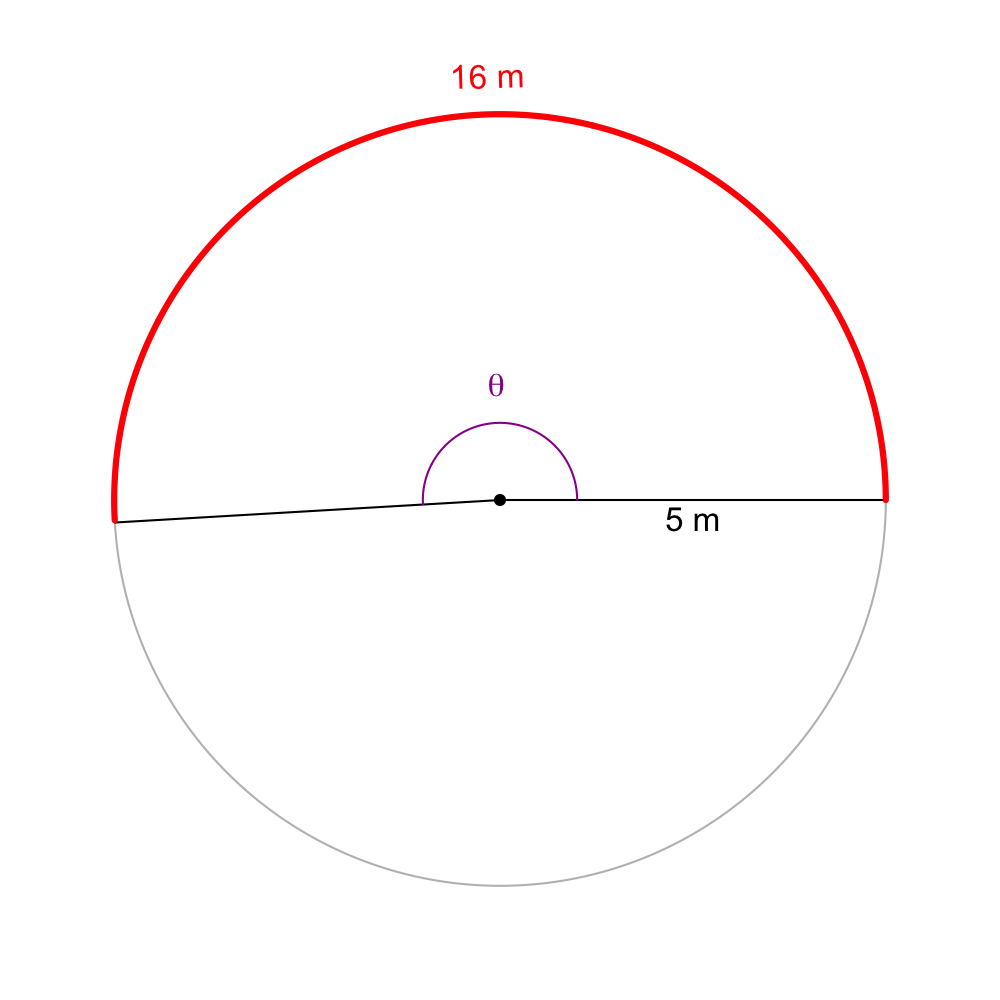

**Find $\theta$ in radians**.

Remember, the radian measure of an angle is the length of the arc on the **[unit circle](https://en.wikipedia.org/wiki/Unit_circle)** subtended by the angle. The circle shown is not a unit circle (its radius is 5), but we can add a unit circle into the drawing.

(Not drawn to scale.)

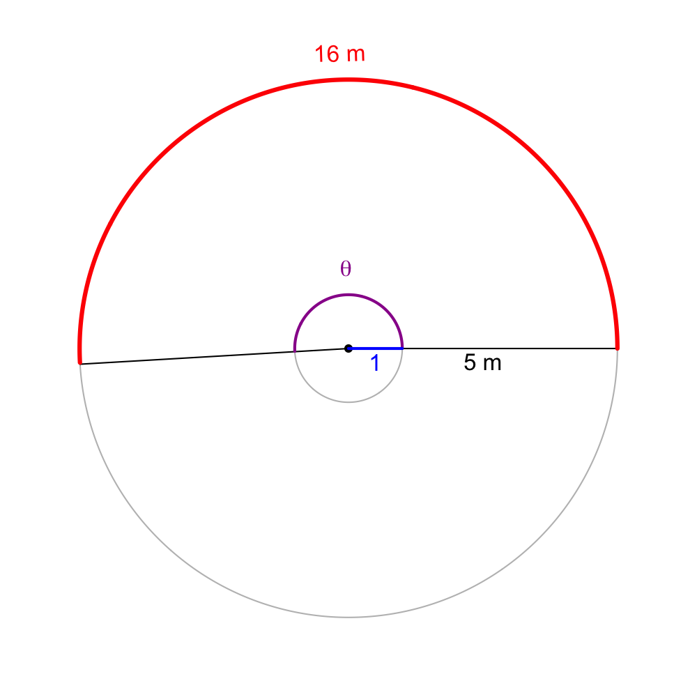

$$\frac{\theta}{16}~=~\frac{1}{5}$$

$$\theta~=~\frac{16}{5}~=~3.2$$

If you refer to the [wikipedia article on circular arcs](https://en.wikipedia.org/wiki/Circular_arc), you'll see a formula:
$$L=\theta r$$
where $L$ is an arc length on a circle of radius $r$ and with central angle $\theta$ (pronounced "theta"). In our case, we were given $L=16$ and $r=5$, so we can rearrange the formula, solving for $\theta$.

$$\theta = \frac{L}{r} =
\frac{16}{5}$$

Consider a circle with a radius of length $r=9.4$ meters. A [central angle](https://en.wikipedia.org/wiki/Central_angle), in [standard position](https://libraryguides.centennialcollege.ca/c.php?g=716824&p=5112868), subtends an arc of length $32.9$ meters.

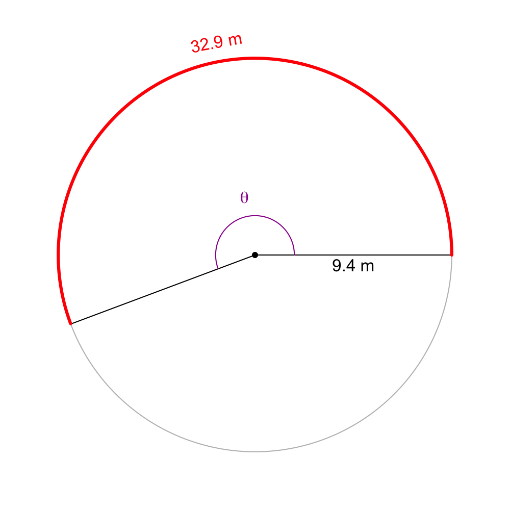

**Find $\theta$ in radians**.

Remember, the radian measure of an angle is the length of the arc on the **[unit circle](https://en.wikipedia.org/wiki/Unit_circle)** subtended by the angle. The circle shown is not a unit circle (its radius is 9.4), but we can add a unit circle into the drawing.

(Not drawn to scale.)

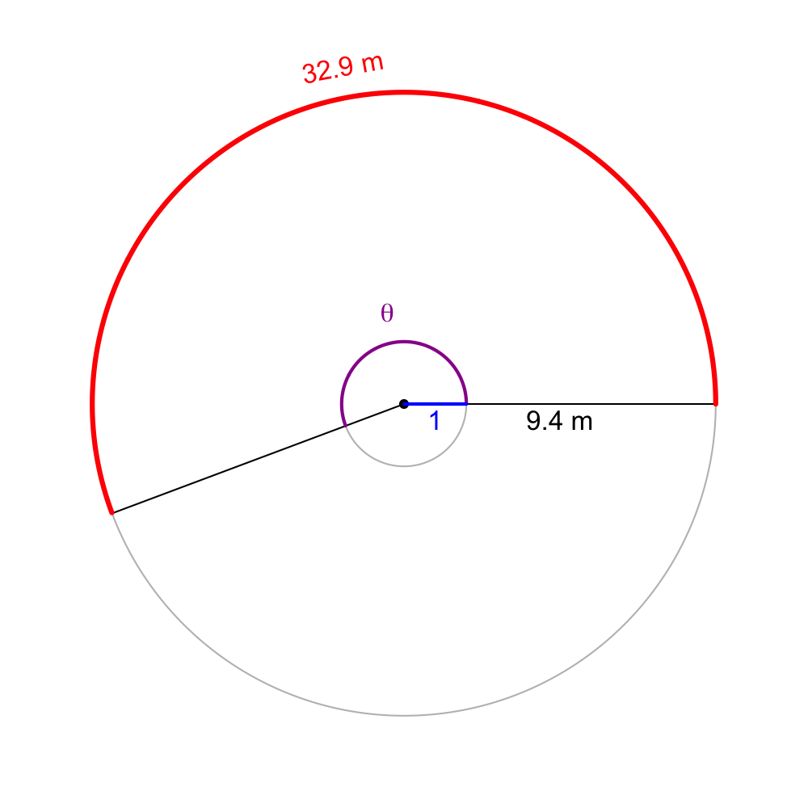

$$\frac{\theta}{32.9}~=~\frac{1}{9.4}$$

$$\theta~=~\frac{32.9}{9.4}~=~3.5$$

If you refer to the [wikipedia article on circular arcs](https://en.wikipedia.org/wiki/Circular_arc), you'll see a formula:
$$L=\theta r$$
where $L$ is an arc length on a circle of radius $r$ and with central angle $\theta$ (pronounced "theta"). In our case, we were given $L=32.9$ and $r=9.4$, so we can rearrange the formula, solving for $\theta$.

$$\theta = \frac{L}{r} =
\frac{32.9}{9.4}$$

Consider a circle with a radius of length $r=4$ meters. A [central angle](https://en.wikipedia.org/wiki/Central_angle), in [standard position](https://libraryguides.centennialcollege.ca/c.php?g=716824&p=5112868), subtends an arc of length $8.6$ meters.

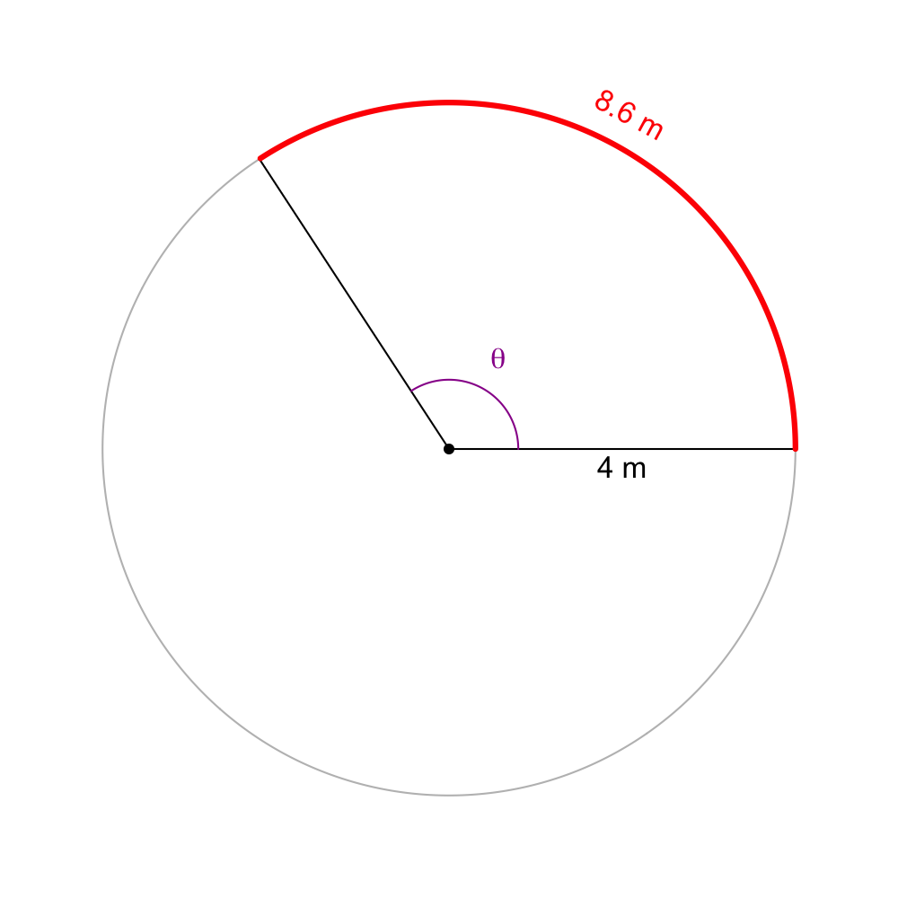

**Find $\theta$ in radians**.

Remember, the radian measure of an angle is the length of the arc on the **[unit circle](https://en.wikipedia.org/wiki/Unit_circle)** subtended by the angle. The circle shown is not a unit circle (its radius is 4), but we can add a unit circle into the drawing.

(Not drawn to scale.)

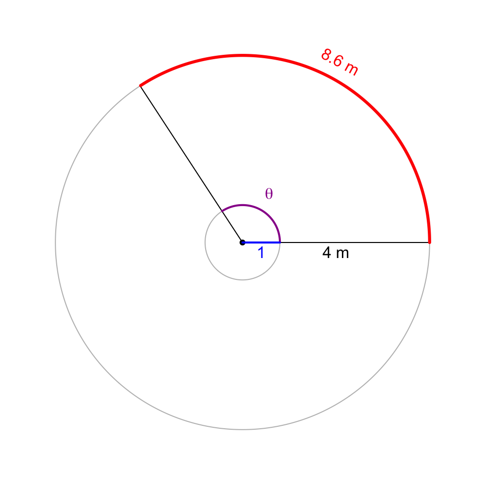

$$\frac{\theta}{8.6}~=~\frac{1}{4}$$

$$\theta~=~\frac{8.6}{4}~=~2.15$$

If you refer to the [wikipedia article on circular arcs](https://en.wikipedia.org/wiki/Circular_arc), you'll see a formula:
$$L=\theta r$$
where $L$ is an arc length on a circle of radius $r$ and with central angle $\theta$ (pronounced "theta"). In our case, we were given $L=8.6$ and $r=4$, so we can rearrange the formula, solving for $\theta$.

$$\theta = \frac{L}{r} =
\frac{8.6}{4}$$